# Bi183_HW7

## Problem 1a

```python
import sys
import networkx as nx
import numpy as np
import matplotlib.pyplot as plt
import math
from sklearn.metrics.pairwise import euclidean_distances
```

```python
class Graph():

    def __init__(self, vertices):
        self.vertices = vertices
        self.graph = [[0 for column in range(vertices)] for row in range(vertices)]

    # prints out the minimum spanning tree with edge and weight
    def print_MST(self, mst):
        print("Edge \tWeight")
        for i in range(1, self.vertices):
            print(mst[i], "-", i, "\t", self.graph[i][mst[i]] )

    # Selects the edge that has the minimum weight
    def min_vertex(self, vset, visited):
        min = sys.maxsize
        for v in range(self.vertices):
            if vset[v] < min and visited[v] == False:
                min = vset[v]
                min_index = v
        return min_index

    # Constructs a minimum spanning tree from the graph
    def find_MST(self):

        # keeps track of the weights of the min path
        # initialized with maximum numbers
        vset = [sys.maxsize] * self.vertices
        # picks the root vertex as the first one
        vset[0] = 0
        # stores the minimum spanning tree
        mst = [None] * self.vertices
        mst[0] = -1
        # keeps track of which nodes have been visited
        visited = [False] * self.vertices
        # graph from networkx is created to make plotting easier
        G = nx.Graph()

        for vertex in range(self.vertices):

            # Get the smallest weight path
            u = self.min_vertex(vset, visited)

            # Mark the vertex as visited
            visited[u] = True

            for v in range(self.vertices):
                # go through all the vertices that haven't been visited
                # if index in vset is greater than the graph edge (not a minimum)
                # update the distance in vset (shortest path weights) and mst (minimum spanning tree)
                if self.graph[u][v] > 0 and visited[v] == False and vset[v] > self.graph[u][v]:
                        vset[v] = self.graph[u][v]
                        mst[v] = u
                        G.add_edge(v, u)
        return mst, sum(vset), G
```

## Problem 1b

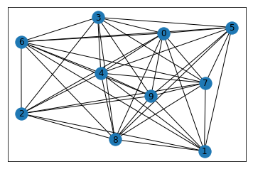

```
Edge 	Weight
0 - 1 	 2
0 - 2 	 1
2 - 3 	 0
1 - 4 	 0
6 - 5 	 2
0 - 6 	 0
5 - 7 	 2
3 - 8 	 2
1 - 9 	 3
```

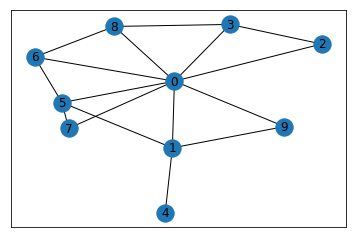

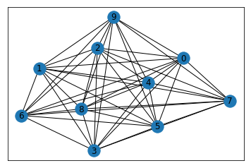

```
Edge 	Weight
0 - 1 	 4
6 - 2 	 2
1 - 3 	 4
3 - 4 	 3
3 - 5 	 3
8 - 6 	 4
0 - 7 	 1
1 - 8 	 4
3 - 9 	 2
```

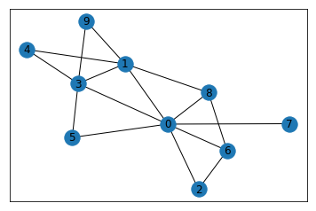

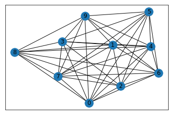

```
Edge 	Weight
3 - 1 	 4
1 - 2 	 4
9 - 3 	 2
0 - 4 	 0
4 - 5 	 0
1 - 6 	 4
1 - 7 	 0
6 - 8 	 1
5 - 9 	 3
```

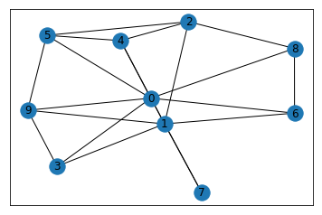

```python
for i in range(3):
    n = 10
    adjacency = np.random.randint(0,5,(n,n))
    g = Graph(n)
    g.graph = adjacency
    plt.figure()
    nx.draw_networkx(nx.from_numpy_matrix(np.asmatrix(g.graph)))
    plt.show()

    m, l, gra = g.find_MST()
    g.print_MST(m)
    plt.figure()
    nx.draw_networkx(gra)
    plt.show()
```

## Problem 1c

Do graphs exist that have more than one minimum spanning tree? If so, construct such a graph.

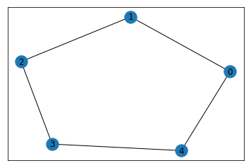

```
Edge 	Weight
0 - 1 	 0
1 - 2 	 1
2 - 3 	 1
0 - 4 	 1
```

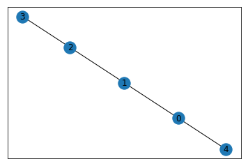

```python
g = Graph(5)
g.graph=[[0, 1, 0, 0, 1],
         [0, 0, 1, 0, 0],
         [0, 1, 0, 1, 0],
         [0, 0, 1, 0, 1],
         [1, 0, 0, 1, 0]
        ]
plt.figure()
nx.draw_networkx(nx.from_numpy_matrix(np.asmatrix(g.graph)))
plt.show()

m, l, gra = g.find_MST()
g.print_MST(m)
plt.figure()
nx.draw_networkx(gra)
plt.show()
```

## Problem 1d

The algorithm in part A is only deterministic if all edge weights are different. Otherwise, another minimum spanning tree may be possible, since when choosing the edge with the lowest weight, these results may be ambiguous. One way to expand this to return all MSTs would be to keep track of two different edges if the min edge weight is the same between multiple edges.

## Problem 2a

Write an algorithm that implements Louvain clustering on a graph by partitioning it into a set of communities.

```python
# naive implementation
def modularity(G, c):
    A = nx.adjacency_matrix(G).todense()
    m = 0.5 * np.sum(A)
    summa = 0
    for i in range(len(A)):
        for j in range(len(np.asarray(A)[0])):
            # degrees of vertex are equal to row sum in adjacency matrix
            # no weights on edges
            ki = np.sum(A[i])
            kj = np.sum(A[j])
            # if communities are not equal
            if c[i] != c[j]:
                d = 0
            else:
                d = 1
            # update the summation
            summa += (np.asarray(A)[i][j] - (ki*kj)/(2*m)) * d
    return (1/(2*m)) * summa

# gets the constant term in the algorithm
def get_const_mtx(G):
    A = nx.adjacency_matrix(G).todense()
    m = 0.5 * np.sum(A)
    mtx = np.zeros((A.shape))
    for i in range(len(A)):
        for j in range(len(np.asarray(A)[0])):
            # degrees of vertex are equal to row sum in adjacency matrix
            # no weights on edges
            ki = np.sum(A[i])
            kj = np.sum(A[j])
            # update the matrix
            mtx[i][j] = (np.asarray(A)[i][j] - (ki*kj)/(2*m))
    return mtx

# optimized modularity function
def modularity_opt(G, c, const):
    A = nx.adjacency_matrix(G).todense()
    m = 0.5 * np.sum(A)
    x, y = np.indices(A.shape)
    comm = np.asarray(c)
    boolarr = np.where(comm[x] == comm[y], 1, 0)
    return np.sum(const * boolarr)

# louvain clustering algorithm
def louvain_cluster(G):
    c = [i for i in G.nodes]
    const = get_const_mtx(G)
    orig_mod = modularity_opt(G, c, const)
    prev_mod = 0
    while True:
        for node in G.nodes:
            neighbors_ = G.neighbors(node)
            max_neighbor_mod = -1*sys.maxsize
            best_neighbor_c = c.copy()
            for n in neighbors_:
                tmp = c.copy()
                # set the community to the neighbor's
                tmp[node] = n
                curr_mod = modularity_opt(G, tmp, const)
                if curr_mod > max_neighbor_mod:
                    max_neighbor_mod = curr_mod
                    best_neighbor_c = tmp.copy()
            # iterated through all neighbors
            # see if the modularity can increase by moving communities
            if max_neighbor_mod > orig_mod:
                c = best_neighbor_c.copy()
                orig_mod = max_neighbor_mod
        if abs(prev_mod - orig_mod) < 0.000001:
            break
        prev_mod = orig_mod
    return c
```

## Problem 2b

Sample points from two multivariate distributions with slight overlap.

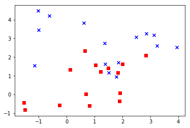

```python
# points in each dataset -> 30 total points
def two_multivariate_distros(points, m1, m2, cov1, cov2):
    x0 = np.random.multivariate_normal(m1, cov1, (1, 1, points))[0][0]
    x1 = np.random.multivariate_normal(m2, cov2, (1, 1, points))[0][0]
    dataset = np.concatenate((x0, x1))
    return x0, x1, dataset

points = 15
mean = (1, 3)
cov = [[2, 0], [0, 2]]
mean1 = (1, 1)
cov1 = [[1, 0], [0, 1]]
x0, x1, dataset = two_multivariate_distros(points, mean, mean1, cov, cov1)
plt.scatter(x0[:,0], x0[:,1], c='b', marker='x', label='1')
plt.scatter(x1[:,0], x1[:,1], c='r', marker='s', label='-1')
```

**Generate data and construct a k-NN graph using the sampled points.**

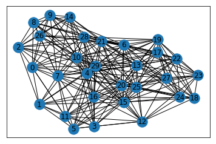

```python
def generate_knn_graph(dataset, nk):
    # create a array of distances between one point in the dataset and the rest of the points
    d = [euclidean_distances(dataset, [dataset[i]]) for i in range(len(dataset))]
    # process the data so it can be used later
    data = []
    for lst in d:
        data.append(lst.flatten())
    # sort the data from nearest -> farthest by argument
    sort = np.argsort(data)
    # 3set the number of neighbors
    k = nk
    # create a graph and add nodes (# of points in dataset)
    G = nx.Graph()
    G.add_nodes_from(range(len(dataset)))
    # build the KNN graph
    for p in range(len(dataset)):
        # exclude the 0th closest neighbor (itself)
        neighbors = sort[p][1:k+1]
        # add an edge to each kth nearest neighbor
        for n in neighbors:
            G.add_edge(p, n)
    return G

G = generate_knn_graph(dataset, 12)
plt.figure()
nx.draw_networkx(G)
plt.show()
```

```python
communities = louvain_cluster(G)
print(communities)
```

```
[2, 5, 2, 5, 5, 5, 23, 2, 2, 2, 2, 5, 5, 23, 2, 5, 5, 23, 23, 23, 23, 2, 23, 23, 23, 23, 2, 23, 2, 2]
```

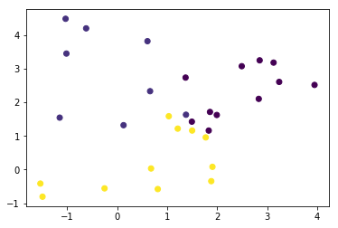

```python
def plot_communities(communities, dataset):
    plt.scatter(dataset[:,0], dataset[:,1], c=communities)
plot_communities(communities, dataset)
```

## Problem 2c

Perform Louvain clustering while changing the space between the centroids (µ1 and µ2) as well as the covariance. Select two more examples of interest and show community architure and K-nn graph. Select your examples to show how Louvain performs when communities become close together.

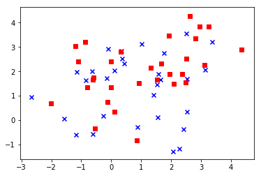

```python
m0 = (1, 1)
m1 = (1, 2)
c0 = [[2, 0], [0, 2]]
c1 = [[2, 1], [1, 2]]
nx0, nx1, ndataset = two_multivariate_distros(30, m0, m1, c0, c1)
plt.scatter(nx0[:,0], nx0[:,1], c='b', marker='x', label='1')
plt.scatter(nx1[:,0], nx1[:,1], c='r', marker='s', label='-1')
```

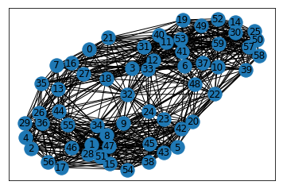

```python
G0 = generate_knn_graph(ndataset, 20)
plt.figure()
nx.draw_networkx(G0)
plt.show()
```

```python
communities0 = louvain_cluster(G0)
print(communities0)
```

```
[21, 17, 17, 21, 17, 43, 57, 21, 17, 17, 57, 57, 21, 21, 57, 17, 21, 17, 21, 57, 43, 21, 57, 43, 43, 57, 17, 21, 17, 17, 57, 57, 21, 21, 17, 21, 17, 57, 17, 57, 57, 57, 43, 17, 17, 43, 17, 17, 57, 57, 57, 17, 57, 57, 17, 17, 17, 57, 57, 57]
```

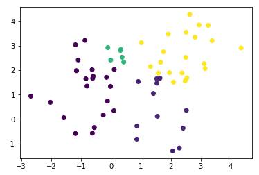

```python
plot_communities(communities0, ndataset)
```

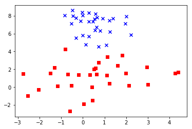

```python
m2 = (1, 7)
m3 = (1, 1)
c2 = [[1, 0], [0, 1]]
c3 = [[3, 0], [0, 3]]
x2, x3, dataset3 = two_multivariate_distros(30, m2, m3, c2, c3)
plt.scatter(x2[:,0], x2[:,1], c='b', marker='x', label='1')
plt.scatter(x3[:,0], x3[:,1], c='r', marker='s', label='-1')
```

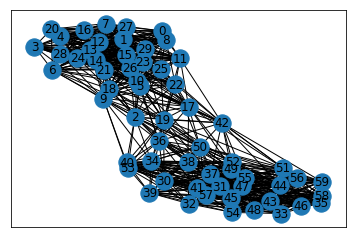

```python
G1 = generate_knn_graph(dataset3, 20)
plt.figure()
nx.draw_networkx(G1)
plt.show()
```

```python
communities1 = louvain_cluster(G1)
print(communities1)
```

```
[27, 27, 17, 27, 27, 17, 27, 27, 27, 17, 17, 27, 27, 27, 27, 27, 27, 17, 17, 17, 27, 27, 17, 27, 27, 17, 27, 27, 27, 27, 40, 40, 40, 46, 40, 46, 40, 40, 40, 40, 40, 40, 17, 46, 46, 40, 46, 40, 46, 40, 40, 46, 40, 40, 46, 40, 46, 40, 46, 46]
```

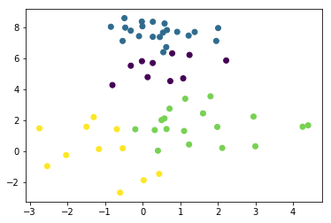

```python
plot_communities(communities1, dataset3)
```

## Problem 2d

Now perform Louvain on synthetic examples of size 10, 50, 100, and plot Q vs iteration on the same plot.

```python
# louvain clustering algorithm
def louvain_cluster_plot(G, state):
    global Q
    global iterations
    c = [i for i in G.nodes]
    const = get_const_mtx(G)
    orig_mod = modularity_opt(G, c, const)
    prev_mod = 0
    while True:
        Q[state].append(orig_mod)
        iterations[state] += 1
        for node in G.nodes:
            neighbors_ = G.neighbors(node)
            max_neighbor_mod = -1*sys.maxsize
            best_neighbor_c = c.copy()
            for n in neighbors_:
                tmp = c.copy()
                # set the community to the neighbor's
                tmp[node] = n
                curr_mod = modularity_opt(G, tmp, const)
                if curr_mod > max_neighbor_mod:
                    max_neighbor_mod = curr_mod
                    best_neighbor_c = tmp.copy()
            # iterated through all neighbors
            # see if the modularity can increase by moving communities
            if max_neighbor_mod > orig_mod:
                c = best_neighbor_c.copy()
                orig_mod = max_neighbor_mod
        if abs(prev_mod - orig_mod) < 0.000001:
            break
        prev_mod = orig_mod
    return c
```

```python
Q = {0:[], 1:[], 2:[]}
iterations = {0:0, 1:0, 2:0}
m5 = (1, 1)
m5_ = (1, 2)
c5 = [[1, 0], [0, 1]]
c5_ = [[2, 0], [0, 2]]
for idx, val in enumerate([5, 25, 50]):
    x5, x5_, dataset5 = two_multivariate_distros(val, m5, m5_, c5, c5_)
    G5 = generate_knn_graph(dataset5, math.floor(val/2))
    comm5 = louvain_cluster_plot(G5, idx)
```

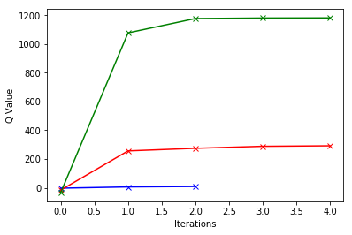

```python
plt.plot(np.arange(iterations[0]), Q[0], c='b', marker='x', label='1')
plt.plot(np.arange(iterations[1]), Q[1], c='r', marker='x', label='1')
plt.plot(np.arange(iterations[2]), Q[2], c='g', marker='x', label='1')
plt.xlabel("Iterations")
plt.ylabel("Q Value")
```

## Problem 3a

Generate a k-NN graph for the PBMC data for k = 4, 10, 20, and plot the resulting k-NN graphs in the 2D space defined by the first two principle components of the data.

```python
import csv
from sklearn.decomposition import PCA
reader = csv.reader(open("pbmc_data_matt.csv"), delimiter=",")
x = list(reader)
# should I log transform and mean center the data before performing PCA?
result = np.log(np.array(x).astype("float")+1)
mean_center = result.copy()
for row in mean_center:
    mean = np.mean(row)
    for i in range(len(row)):
        row[i] -= mean
```

```python
mask = np.random.choice([False, True], len(mean_center.T), p=[0.75, 0.25])
cells = mean_center.T[mask]
gene_cov = (1 / (len(cells.T) - 1)) * np.dot(cells.T , cells)
eigv, eigvec = np.linalg.eig(gene_cov)
eigvec = np.asarray(eigvec)[:,:3]
print(eigvec[:,0])
```

```
[ 8.01706659e-02  8.30285423e-02  7.88552237e-02 ...  1.02686636e-03
 -6.95761859e-07 -9.12285303e-06]
```

```python
xp = np.asmatrix(pca.components_[0])
yp = np.asmatrix(pca.components_[1])
data = np.asarray(np.concatenate((xp.T, yp.T), axis=1))[:300]
```

```python
mask = np.random.choice([False, True], len(mean_center.T), p=[0.9375, 0.0625])
cells = mean_center.T[mask]
print(cells.T.shape)
```

```
(1618, 492)
```

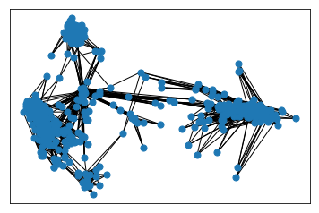

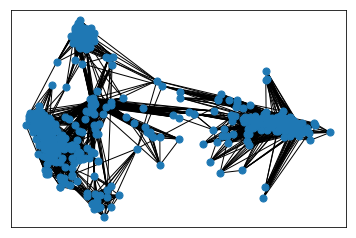

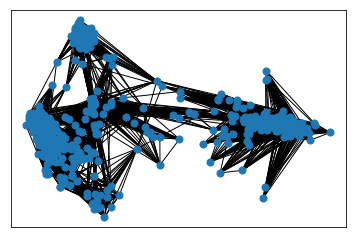

```python
for k in [4, 10, 20]:
    tmp = generate_knn_graph(cells, k)
    pos = {}
    for node in tmp.nodes:
        pos[node] = np.asarray([np.dot(eigvec[:,0], cells.T[:,node]), np.dot(eigvec[:,1], cells.T[:,node])])
    plt.figure()
    nx.draw_networkx_nodes(tmp, pos, node_size=50)
    nx.draw_networkx_edges(tmp, pos)
    plt.show()
```

## Problem 3b

Perform Louvain clustering using your code for k = 4.

```python
G4 = generate_knn_graph(cells, 4)
louvain_4 = louvain_cluster(G4)
```

## Problem 3c

Plot the cells from the data set in 2D and 3D pca space defined by the first 2 or 3 PCs and color points by community.

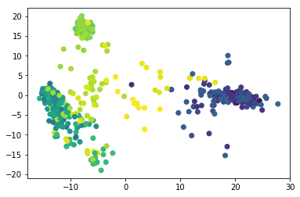

```python
plt.scatter(np.dot(eigvec[:,0], cells.T), np.dot(eigvec[:,1], cells.T), c=louvain_4)
```

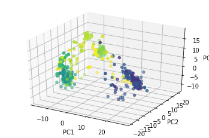

```python
from mpl_toolkits.mplot3d import Axes3D
fig = plt.figure()
ax = fig.add_subplot(111, projection='3d')
ax.scatter(np.dot(eigvec[:,0], cells.T), np.dot(eigvec[:,1], cells.T), np.dot(eigvec[:,2], cells.T), c=louvain_4)
ax.set_xlabel('PC1')
ax.set_ylabel('PC2')
ax.set_zlabel('PC3')
plt.show()
```

We can observe that visually, the data generally clusters in three areas, and that there are around 5-6 communities based on the dominant colors shown in the graph. In general, the same colors are near each other, forming clusters of points, though the yellow points seem to capture those points in between the clusters of cell data. In general, there seems to be three dominant colors, where most of the green points are on the left side of the graph, the light green points are near the top, and the dark blue/purplr points are near the right edges.

## Problem 3d

Generate a heatmap of the data matrix where you include a new row that colors cell by community.

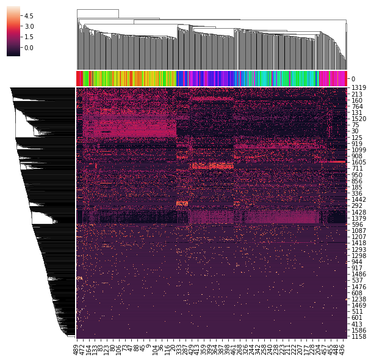

```python
import seaborn as sns
import pandas as pd

matrixx = pd.DataFrame(cells.T)
labels = louvain_4
lut = dict(zip(set(labels), sns.hls_palette(len(set(labels)), l=0.5, s=0.8)))
colors = pd.DataFrame(labels)[0].map(lut)
sns.clustermap(matrixx, col_colors=colors)
```

As seen above, there seems to be many color communities present, though the scatterplot shows dominant communities/colors. The less precise clustering may be due to the fact that the Louvain algorithm is two parts, and with a low k=4 value, since we only implemented the first half, the clustering may not turn out to be as accurate.